# Financial and Health Impacts of U.S. Storms From 1996 Through 2011

Dave Patterson

November 16, 2015

## Synopsis

The purpose of this report is to explore the NOAA Storm Database and analyze the types of storm events to understand  
1. which are most harmful with respect to population health and  
2. which have the greatest economic consequences?  
This analysis should help to prioritize resources to prepare for severe weather events.

Prior to 1996, there was no standard classification of storm types. Effective beginning in 1996, storm events were grouped into 48 standard event types. Prior to that, the storm data was both sparse and inconsistent. In addition, due to inflation, the value of money prior to 1996 in comparison to today was significantly great enough to potentially skew the data. For these reasons, we will only work with the last 15 years of the data available.

## Data Processing

A copy of the United States National Oceanic and Atmospheric Administration’s (NOAA) storm database was downloaded from the John Hopkins Data Science Coursera course repository for all the storms in the United States from 1950 through 2011. The data was downloaded September 19, 2015.

```r
packages <- c("data.table", "dplyr", "lubridate", "stringr", "ggplot2", "cowplot")
sapply(packages, require, character.only = TRUE, quietly = TRUE, warn.conflicts = FALSE)
```

```
## data.table      dplyr  lubridate    stringr    ggplot2    cowplot
##       TRUE       TRUE       TRUE       TRUE       TRUE       TRUE
```

```r
original.data  <- "http://www.ncdc.noaa.gov/stormevents/details.jsp"
repo.host      <- "http://d396qusza40orc.cloudfront.net/repdata/"
storm.data.url <- paste0(repo.host, "data/StormData.csv.bz2")
storm.data.doc <- paste0(repo.host, "peer2_doc/pd01016005curr.pdf")
storm.data.faq <- paste0(repo.host, "peer2_doc/NCDC%20Storm%20Events-FAQ%20Page.pdf")
storm.data.bz2 <- "StormData.csv.bz2"
storm.data.events.file <- "StormDataEventTable.csv"

# if the data file is not already present, get the source data file
if(!(file.exists(storm.data.bz2))) {
  download.file(storm.data.url, destfile = storm.data.bz2)
}
```

Given the large volume of data (over 900,000 storm events), we only read in the data needed to answer the two questions of interest. This will eliminate two thirds of the data fields and simplify, as well as speed up, the processing of the data. In the list below, “NULL” indicates that data field is ignored in this analysis.

```r
# grab the headers
storm.data.headers <- names(read.csv(storm.data.bz2, header = TRUE, nrow = 1))
# create a vector to ignore most of the variables when we read them in since
# we're not interested in most of them -- only in data the can affect the
# answers i.e. storm data that impacts health or property
header.char.classes <- rep("NULL", 37)
# set the variables we are interested in to type char so they read in quickly
header.char.classes[c(2,8,23:28,36,37)] <- "character"
# verify the mapping
cbind(storm.data.headers, header.char.classes)
```

```
##       storm.data.headers header.char.classes
##  [1,] "STATE__"          "NULL"
##  [2,] "BGN_DATE"         "character"
##  [3,] "BGN_TIME"         "NULL"
##  [4,] "TIME_ZONE"        "NULL"
##  [5,] "COUNTY"           "NULL"
##  [6,] "COUNTYNAME"       "NULL"
##  [7,] "STATE"            "NULL"
##  [8,] "EVTYPE"           "character"
##  [9,] "BGN_RANGE"        "NULL"
## [10,] "BGN_AZI"          "NULL"
## [11,] "BGN_LOCATI"       "NULL"
## [12,] "END_DATE"         "NULL"
## [13,] "END_TIME"         "NULL"
## [14,] "COUNTY_END"       "NULL"
```

[output cut: 23 more lines]

The data is loaded and prepared for analysis. Three levels of filters applied:  
1. Date: only the storm data collected after January 1, 1996 is used  
2. Fields: only the fields needed to answer the questions, as shown in the table above, is used  
3. Impact: only storm events that had a health or financial impact is used

The date filter still leaves nearly two thirds of a million storm events, many of which have no impact on the questions we are looking to answer. The impact filter eliminates more than two thirds of the storm events in the 15 year period, but still leaves a bit over 200,000 storm events, all of which have a bearing on the two questions.

```r
# read in only the variables we're interested in and only the data after the new
# stardard has gone into effect and that has an impact on the questions Ignoring
# the early data removes the most noise and about a third of the data
storm.data <- tbl_df(read.csv(storm.data.bz2,
                              stringsAsFactors=FALSE,
                              # filter the fields
                              colClasses = header.char.classes))  %>%
              # filter by date
              mutate(BGN_DATE =  mdy_hms(BGN_DATE)) %>%
              filter(BGN_DATE >= "1996-01-01") %>%
              # coerce the numeric data to be the correct type
              mutate(FATALITIES = as.integer(FATALITIES),
                     INJURIES = as.integer(INJURIES),
                     PROPDMG = as.numeric(PROPDMG),
                     CROPDMG = as.numeric(CROPDMG),
                     REFNUM = as.integer(REFNUM)) %>%
              # finally keep only the storm data that can affect the questions;
              # this removes about two thirds of the remaining data, none of
              # which helps answer the questions since we're looking at totals,
              # not averages
              filter(FATALITIES > 0 | INJURIES > 0 | PROPDMG > 0 | CROPDMG > 0)
```

In a first look at the storm data, we can see the storm event types do not always align with the standard event names.

```r
# read in the standard event types used starting 1996
# extracted from storm.data.doc file (Table 1. Storm Data Event Table)
standard_events <- read.csv(storm.data.events.file,
                            comment.char = "#",
                            stringsAsFactors = FALSE)

# and from our storm data
storm.data.events <- unique(storm.data$EVTYPE)
```

The remaining storm data contains **222** unique storm event types in contrast to the 48 standard event types. It would greatly simplify the analysis if the 222 unique storm event types could be grouped into the 48 standard event types. Since the filtered data contains 201313 storm events, it is obvious that we’ll need some tools to help with the analysis. These functions were useful in exploring and cleaning the storm data.

```r
# define a function to select storm events from the data set based on regular
# expressions this aids in generating regexps to group events into std types
get_event <- function(src, pattern) {
  unique(grep(pattern, src, ignore.case = TRUE, value = TRUE))
}
# and an example call
# get_event(events, "^\\s*(tstm|thunder)")

# define a function to get the remarks for a specific storm reference
get_remarks_for <- function(ref) {
  storm.data[(storm.data$REFNUM == ref),"REMARKS"]
}

# define a function to replace the dirty event types with standard names
# NOTE that argument order is set to allow pipelining
replace_event <- function(src, pattern, replacement) {
  idx <- grepl(pattern, src$EVTYPE, ignore.case = TRUE)
  src[idx, "EVTYPE"] <- replacement
  src
}

# define a function to replace the dirty event types with standard names while
# excluding a specific phrase or word
# NOTE that argument order is set to allow pipelining
replace_event_wo <- function(src, pattern, exclude, replacement) {
  idx <- grepl(pattern, src$EVTYPE, ignore.case = TRUE) &
         !grepl(exclude, src$EVTYPE, ignore.case = TRUE)
  src[idx, "EVTYPE"] <- replacement
  src
}
```

Using these functions almost all of the storm data events can be mapped into the standard events.

```r
# Use regular expressions to map the dirty event type fields into standard names
storm.data <- select(storm.data, c(1:8,10)) %>%
  replace_event("^Astronomical Low Tide",
                "Astronomical Low Tide") %>%
  replace_event("(coast|cstl|beach).*(flood|erosion)",
                "Coastal Flood") %>%
  replace_event("^(extended )*cold",
                "Cold/Wind Chill") %>%
  replace_event("^(land|mud|rock).*(slide|slump)",
                "Debris Flow") %>%
  replace_event_wo("fog",
                   "freezing",
                   "Dense Fog") %>%
  replace_event_wo("dust",
                   "devil",
                   "Dust Storm") %>%
  replace_event("dust devil",
                "Dust Devil") %>%
  replace_event("^(heat wave|(excessive|record) heat)",
                "Excessive Heat") %>%
  replace_event("^((extreme|unseason).*(cold|chill)|hyp(o|er)thermia)",
                "Extreme Cold/Wind Chill") %>%
  replace_event("^\\s*flash.*flood",
                "Flash Flood") %>%
  replace_event("^(((ice jam|river)*\\s*flood)|urban.*fld|high water)",
                "Flood") %>%
  replace_event_wo("(freez|frost)",
                   "fog",
                   "Frost/Freeze") %>%
  replace_event("^(funnel|whirlwind)",
                "Funnel Cloud") %>%
  replace_event("^(small )?hail",
                "Hail") %>%
  replace_event("(^heat$|warm)",
                "Heat") %>%
  replace_event("^((heavy|hvy|torrential|unseasonal).*rain|rain)",
                "Heavy Rain") %>%
  replace_event("^((heavy|excessive).*snow|snow squall)",
                "Heavy Snow") %>%
  replace_event("^\\s*(high|heavy|rough|hazardous).*(surf|seas|swell)",
                "High Surf") %>%
  replace_event("^Hurricane|Typhoon",
                "Hurricane (Typhoon)") %>%
  replace_event_wo("(ic[ey]|glaze)",
                   "jam",
                   "Ice Storm") %>%
  replace_event("^lake.*snow",
                "Lake-Effect Snow") %>%
  replace_event("^Marine (Thunderstorm|Tstm) Wind",
                "Marine Thunderstorm Wind") %>%
  replace_event("^rip current",
                "Rip Current") %>%
  replace_event("^Seiche|(astro.*)?high tide",
                "Seiche") %>%
  replace_event("^(storm surge|coast.*storm|tidal|rogue|high tide)",
                "Storm Surge/Tide") %>%
  replace_event_wo("(Strong Wind|wind damage|(down|micro)burst)",
                   "marine",
                   "Strong Wind") %>%
  replace_event("^\\s*(tstm|thunder).*",
                "Thunderstorm Wind") %>%
  replace_event_wo("wind",
                   "chill|marine|strong|thunder",
                   "High Wind") %>%
  replace_event("^(water|land)spout",
                "Waterspout") %>%
  replace_event("fire",
                "Wildfire") %>%
  replace_event_wo("((wint[ery]+ (weather|mix))|snow|mixed precip)",
                   "heavy|excessive|lake",
                   "Winter Weather") %>%
  replace_event("other|marine accident|drowning", "Other") %>%
  mutate(EVTYPE = as.factor(str_to_title(EVTYPE)))

other_events <- storm.data$EVTYPE[storm.data$EVTYPE == "Other"]
```

## Results

```r
# Show the table of counts of all event types
table(storm.data$EVTYPE)
```

```
##
##    Astronomical Low Tide                Avalanche                 Blizzard
##                        2                      264                      228
##            Coastal Flood          Cold/Wind Chill                Dam Break
##                      196                      115                        2
##              Debris Flow                Dense Fog              Dense Smoke
##                      201                      159                        1
##                  Drought               Dust Devil               Dust Storm
##                      258                       84                       97
##           Excessive Heat  Extreme Cold/Wind Chill              Flash Flood
##                      687                      307                    19013
##                    Flood             Freezing Fog             Frost/Freeze
##                    10305                        7                      177
##             Funnel Cloud                     Hail                     Heat
##                       12                    22690                      170
##               Heavy Rain               Heavy Snow                High Surf
##                     1056                     1063                      224
##                High Wind      Hurricane (Typhoon)                Ice Storm
##                     5528                      208                      671
##         Lake-Effect Snow          Lakeshore Flood                Lightning
##                      198                        5                    11151
##              Marine Hail         Marine High Wind       Marine Strong Wind
##                        2                       19                       46
## Marine Thunderstorm Wind                    Other              Rip Current
##                      142                       36                      603
##                   Seiche         Storm Surge/Tide              Strong Wind
##                       17                      226                     3496
##        Thunderstorm Wind                  Tornado      Tropical Depression
##                   105370                    12365                       35
##           Tropical Storm                  Tsunami             Volcanic Ash
##                      410                       14                        2
##               Waterspout                 Wildfire             Winter Storm
##                       29                     1229                     1459
##           Winter Weather
##                      734
```

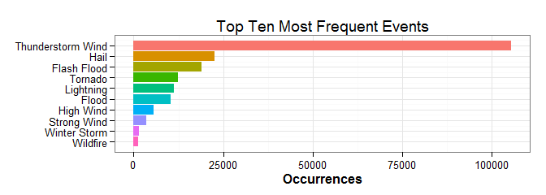

```r
# function to plot horizontal barchart of top ten events most impactful events
# for an impact evdata should be a "tbl_df" of ten rows, with the name of the
# storm event as the first column and the count of the impact (frequency,
# fatalities, injuries, or damage) as the second column
tt_plot <- function(evdata, title, cnt_label) {
  evdata %>%
  setnames(c("Event", "Count")) %>%
  mutate(Event = factor(as.character(Event),
                        levels=Event)) %>%
  ggplot(aes(x = desc(Event),
             y = Count,
             fill = Event)) +
         geom_bar(stat="identity") +
         scale_x_continuous(breaks = (-1:-10),
                            labels = evdata$Event) +
         guides(fill=FALSE) +
         ggtitle(title) +
         ylab(cnt_label) +
         coord_flip() +
         theme_bw() +
         theme(axis.title.y = element_blank())
}

# Plot the ten most frequent events (tte = top ten events)
tte <- head(sort(table(storm.data$EVTYPE),
                 decreasing = TRUE), 10) %>%
       as.data.table(keep.rownames = TRUE)
tt_plot(tte, "Top Ten Most Frequent Events", "Occurrences")
```

### Health Impacts

Here are the top ten storm event types that have an impact on public health, broken out by Fatalities and Injuries.

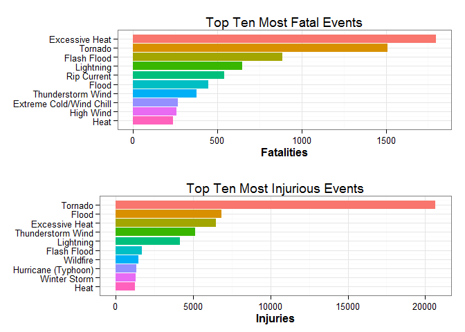

```r
# top ten events causing the most fatalities
ttf <- tbl_df(aggregate(FATALITIES ~ EVTYPE, storm.data, sum)) %>%
       arrange(desc(FATALITIES)) %>%
       head(10)
ttfp <- tt_plot(ttf, "Top Ten Most Fatal Events", "Fatalities")

# top ten events causing the most injuries
tti <- tbl_df(aggregate(INJURIES ~ EVTYPE, storm.data, sum)) %>%
       arrange(desc(INJURIES)) %>%
       head(10)
ttip <- tt_plot(tti, "Top Ten Most Injurious Events", "Injuries")

# Print both graphs as a single plot
plot_grid(ttfp, ttip, nrow = 2)
```

### Financial Impacts

Here are the top ten storm event types that have a financial impact, broken out by property damage and crop damage.

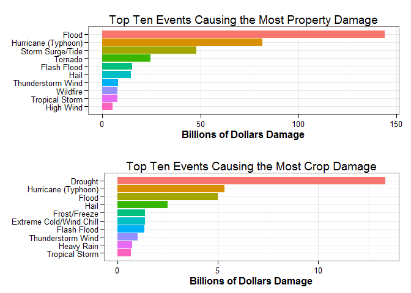

```r
# Apply the exponents to the damage costs, then total by event types
# What is the multiplier of the EXP variables
## Convert to billions of dollars
get_exp_val <- function (exp_var) {
  switch(exp_var,
         "K" = 10^-6,
         "M" = 10^-3,
         "B" = 1,
         10^-9)
}

# normalize the asset damage
storm.data <- storm.data %>%
              mutate(PROPDMGNORM = PROPDMG * sapply(PROPDMGEXP, get_exp_val)) %>%
              mutate(CROPDMGNORM = CROPDMG * sapply(CROPDMGEXP, get_exp_val)) %>%
              group_by(EVTYPE)

# top ten events causing the most property damage
ttp <- tbl_df(aggregate(PROPDMGNORM ~ EVTYPE, storm.data, sum)) %>%
       arrange(desc(PROPDMGNORM)) %>%
       head(10)
ttpp <- tt_plot(ttp,
                "Top Ten Events Causing the Most Property Damage",
                "Billions of Dollars Damage")

# top ten events causing the most crop damage
ttc <- tbl_df(aggregate(CROPDMGNORM ~ EVTYPE, storm.data, sum)) %>%
       arrange(desc(CROPDMGNORM)) %>%
       head(10)
ttcp <- tt_plot(ttc,
                "Top Ten Events Causing the Most Crop Damage",
                "Billions of Dollars Damage")

# Print both graphs as a single plot
plot_grid(ttpp, ttcp, nrow = 2)
```